# Transformations

Dr. Lucy D’Agostino McGowan

## Why transform?

Transformations are powerful tools in regression analysis that help us:

1. **Stabilize variance** (transforming the response)
2. **Model non-linear relationships** (transforming predictors)
3. **Meet model assumptions** (normality, linearity, homoscedasticity)

# Transforming the Response Variable

## Why Transform the Response?

Non-constant variance (heteroscedasticity)

**Solution:** Transform $y$ to stabilize variance

## Example: Non-Constant Variance

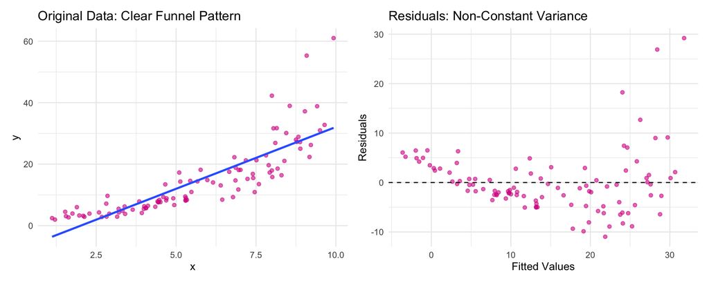

## Common Transformations

**Log transformation:** $\log(y)$

- Use when variance increases with mean
- Multiplicative errors become additive
- Can’t use with zero or negative values

## Common Transformations

**Square root transformation:** $\sqrt{y}$

- Use for count data
- Stabilizes variance for Poisson-like data
- Works with zeros

## Applying a Log Transformation

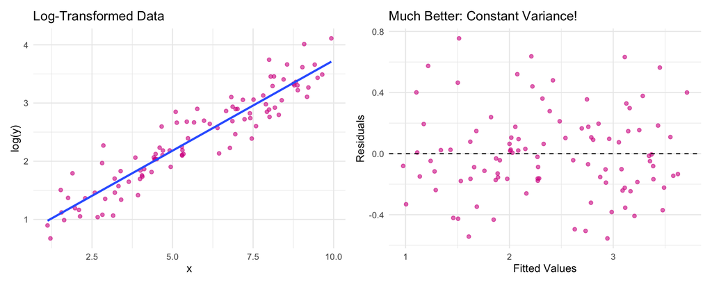

## Back-Transformation

$$\log(y) = \hat\beta_0 + \hat\beta_1 x_1...\hat\beta_px_p$$

$$\hat{y}=e^{\hat\beta_0}e^{\hat\beta_1x_1}... e^{\hat\beta_px_p}$$

## Handling Zeros in Log Transformation

**Problem:** $\log(0)$ is undefined

**Common solution:** Add a small constant

$$\log(y + c)$$

where $c$ is a small positive number (e.g., 0.5 or 1)

# Transforming Predictor Variables

## Why Transform Predictors?

**Problem:** Relationship between $y$ and $x$ is non-linear

**Solution:** Include functions of $x$ in the model

- Polynomials: $x, x^2, x^3, \ldots$
- Splines: piecewise polynomials
- Other: $\log(x)$, $\sqrt{x}$, etc.

## Polynomial Regression

**Model:**
$$y = \beta_0 + \beta_1 x + \beta_2 x^2 + \cdots + \beta_p x^p + \varepsilon$$

**Interpretation changes!**

- Can no longer say “one-unit increase in $x$”
- Effect of $x$ depends on current value of $x$

## Polynomial Example

```r
set.seed(1)
n <- 100
x <- runif(n, 0, 10)
y <- 2 + 3*x - 0.3*x^2 + rnorm(n)

# Linear model (wrong)
model_linear <- lm(y ~ x)

# Quadratic model (correct)
model_quad <- lm(y ~ x + I(x^2))

# Create grid for predictions
x_grid <- seq(0, 10, length.out = 100)
pred_linear <- predict(model_linear,
                       newdata = data.frame(x = x_grid))
pred_quad <- predict(model_quad,
                     newdata = data.frame(x = x_grid))

ggplot() +
  geom_point(aes(x = x, y = y), alpha = 0.5, color = "#d5008f") +
  geom_line(aes(x = x_grid, y = pred_linear, color = "Linear"),
            linewidth = 1) +
  geom_line(aes(x = x_grid, y = pred_quad, color = "Quadratic"),
            linewidth = 1) +
  scale_color_manual(values = c("Linear" = "blue", "Quadratic" = "#d5008f")) +
  labs(title = "Linear vs. Quadratic Fit",
       x = "x", y = "y", color = "Model") +
  theme_minimal() +
  theme(legend.position = "top")
```

## Polynomial Example

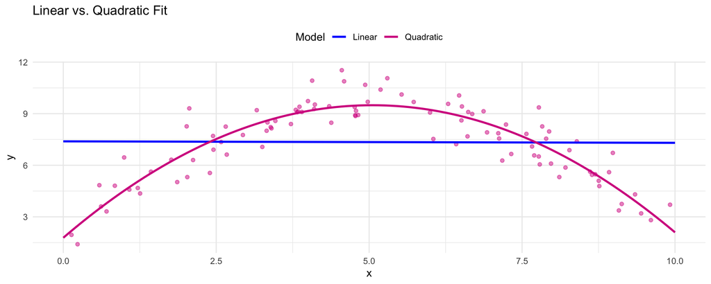

## Interpreting Polynomial Coefficients

```r
summary(model_quad)$coefficients
```

```
              Estimate Std. Error    t value     Pr(>|t|)
(Intercept)  1.7843701 0.33890355   5.265126 8.415039e-07
x            3.0510477 0.15075659  20.238237 1.365512e-36
I(x^2)      -0.3019554 0.01445945 -20.882915 1.144029e-37
```

## IQR-Based Interpretation

**When you don’t have a specific change in mind:**  
Use the interquartile range (IQR) of $x$

```r
q1 <- quantile(x, 0.25)
q3 <- quantile(x, 0.75)

# Predicted values at Q1 and Q3
pred_q1 <- predict(model_quad, newdata = data.frame(x = q1))
pred_q3 <- predict(model_quad, newdata = data.frame(x = q3))

# IQR change
iqr_change <- pred_q3 - pred_q1
```

Predicted $y$ at Q1 (3.23): 8.49  
Predicted $y$ at Q3 (7.67): 7.419  
Change for IQR increase in $x$: -1.071

**Why IQR?** Represents a “typical” change in $x$

## IQR-change

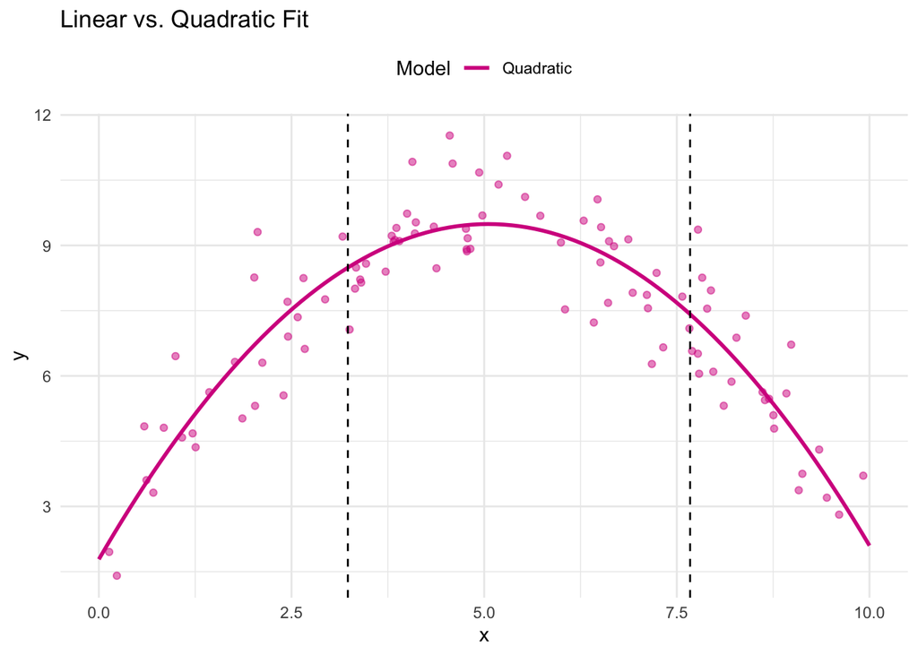

## Restricted Cubic Splines (Natural Splines)

**Better than polynomials for flexible modeling**

**Key idea:**

- Piecewise cubic polynomials
- Joined smoothly at “knots”
- Linear beyond boundary knots
- Doesn’t oscillate wildly at boundaries

## Why Splines?

**Problems with high-degree polynomials:**

- Unstable at boundaries
- All coefficients change when you add data
- Global influence: one point affects fit everywhere

**Advantages of splines:**

- Local influence: only nearby regions affected
- Stable, smooth fits
- More degrees of freedom where you need them

## Splines: Visual Intuition

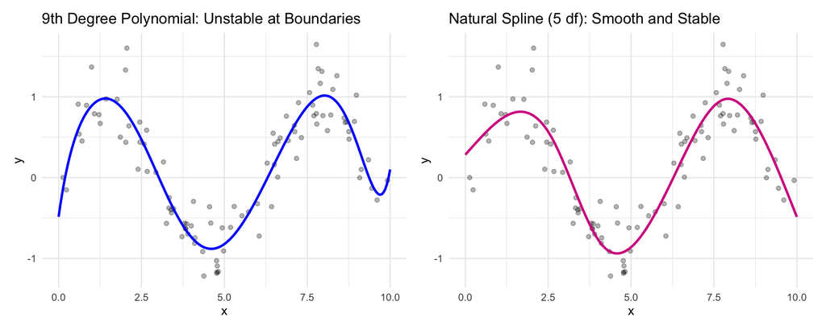

## Using Splines in R

**The `splines` package provides `ns()` function**

```r
library(splines)

# Fit model with natural spline
# df = degrees of freedom (flexibility)
model_spline <- lm(y ~ ns(x, df = 4))

# Look at coefficients
coef(model_spline)
```

```
   (Intercept) ns(x, df = 4)1 ns(x, df = 4)2 ns(x, df = 4)3 ns(x, df = 4)4
     0.6434110     -2.6657928      1.4944870     -0.1684378     -1.1756994
```

**Interpretation:** Still no “one-unit” change!

Must evaluate predicted values at specific $x$ values

## Choosing Degrees of Freedom

**df controls flexibility:**

- Smaller df = smoother, less flexible
- Larger df = more flexible, risk overfitting

```r
model_df3 <- lm(y ~ ns(x, df = 3))
model_df6 <- lm(y ~ ns(x, df = 6))
model_df10 <- lm(y ~ ns(x, df = 10))

x_grid <- seq(min(x), max(x), length.out = 200)
pred_df3 <- predict(model_df3, newdata = data.frame(x = x_grid))
pred_df6 <- predict(model_df6, newdata = data.frame(x = x_grid))
pred_df10 <- predict(model_df10, newdata = data.frame(x = x_grid))

ggplot() +
  geom_point(aes(x = x, y = y), alpha = 0.3) +
  geom_line(aes(x = x_grid, y = pred_df3, color = "df = 3"), linewidth = 1) +
  geom_line(aes(x = x_grid, y = pred_df6, color = "df = 6"), linewidth = 1) +
  geom_line(aes(x = x_grid, y = pred_df10, color = "df = 10"), linewidth = 1) +
  scale_color_manual(values = c("df = 3" = "blue",
                                 "df = 6" = "#d5008f",
                                 "df = 10" = "orange")) +
  labs(title = "Effect of Degrees of Freedom",
       x = "x", y = "y", color = "Model") +
  theme_minimal() +
  theme(legend.position = "top")
```

## Choosing Degrees of Freedom

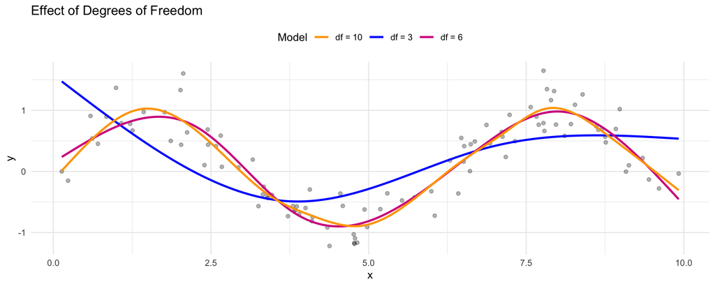

## Creating Spline Basis “By Hand”

**What does `ns()` actually do?**

It creates a design matrix with basis functions

```r
# Create spline basis matrix
x_example <- c(1, 2, 3, 4, 5)
basis_matrix <- ns(x_example, df = 3)

# This is what gets multiplied by coefficients
basis_matrix
```

```
               1         2          3
[1,]  0.00000000 0.0000000  0.0000000
[2,] -0.08921458 0.4785813 -0.3190542
[3,]  0.32047336 0.4760799 -0.2965533
[4,]  0.50226181 0.3213396  0.1060861
[5,] -0.14285714 0.4285714  0.7142857
attr(,"degree")
[1] 3
attr(,"knots")
[1] 2.333333 3.666667
attr(,"Boundary.knots")
[1] 1 5
attr(,"intercept")
[1] FALSE
attr(,"class")
[1] "ns"     "basis"  "matrix"
```

Each column is a basis function evaluated at the $x$ values

## Design Matrix for Splines

```r
# Generate some x values
x_vals <- seq(0, 10, length.out = 100)

# Create design matrix manually
X <- cbind(1, ns(x_vals, df = 4))

# Look at structure
dim(X)
```

```
[1] 100   5
```

```r
head(X, 3)
```

```
                  1           2          3           4
[1,] 1 0.000000e+00  0.00000000 0.00000000  0.00000000
[2,] 1 1.099317e-05 -0.01023872 0.03071616 -0.02047744
[3,] 1 8.794540e-05 -0.02044399 0.06133197 -0.04088798
```

**Design matrix has:**

- First column: intercept (all 1s)
- Remaining columns: spline basis functions

## Fitting with Design Matrix “By Hand”

```r
# Create response and design matrix
set.seed(1)
n <- 50
x <- runif(n, 0, 10)
y <- sin(x) + rnorm(n, sd = 0.3)

# Design matrix: intercept + spline basis
X <- cbind(1, ns(x, df = 4))

# Solve normal equations manually
beta_hat <- solve(t(X) %*% X) %*% t(X) %*% y

# Compare to lm()
model <- lm(y ~ ns(x, df = 4))

data.frame(
  manual = round(as.vector(beta_hat), 4),
  lm_function = round(coef(model), 4)
)
```

```
                manual lm_function
(Intercept)     0.4543      0.4543
ns(x, df = 4)1 -2.3171     -2.3171
ns(x, df = 4)2  1.6965      1.6965
ns(x, df = 4)3  0.2911      0.2911
ns(x, df = 4)4 -1.3703     -1.3703
```

## Visualizing Spline Basis Functions

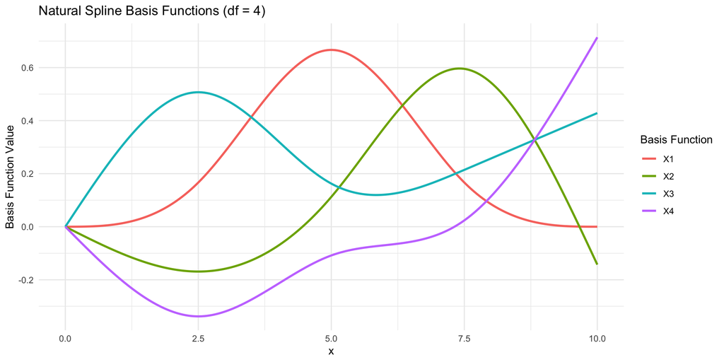

The predicted curve is a weighted sum of these basis functions!

## Natural Splines: The Big Picture

Natural splines are **piecewise cubic polynomials** joined smoothly at knots

## Step 1: Choose Knot Locations

**Knots** are the points where polynomial pieces connect

For df = 4, we typically use 3 interior knots

**Placement:** Usually at quantiles of the data

- 1st knot at 25th percentile
- 2nd knot at 50th percentile
- 3rd knot at 75th percentile

## Knot Placement Example

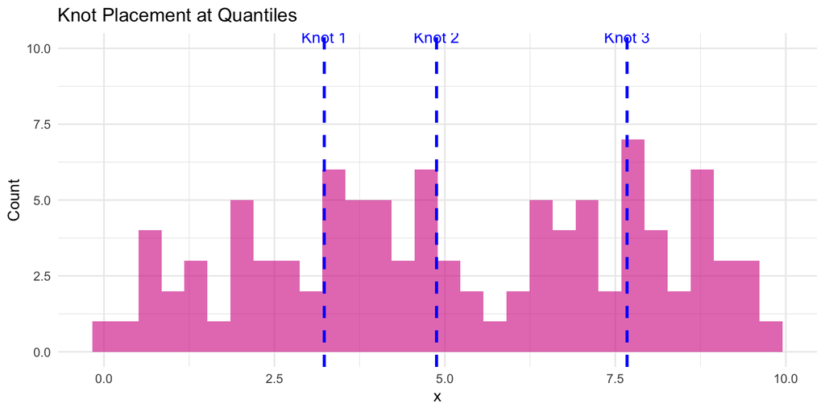

## Step 2: Between Knots, Use Cubic Polynomials

Between each pair of knots, the function is a **cubic polynomial**:

$$f_i(x) = a_i + b_i x + c_i x^2 + d_i x^3$$

With 3 interior knots, we have **4 regions** (4 different cubics)

## Visualizing Piecewise Cubics

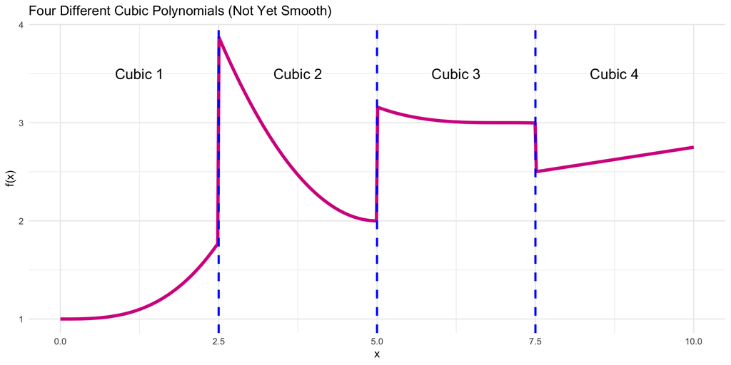

## Problem: Piecewise Cubics Can Be Jumpy

Without constraints, polynomials don’t connect smoothly!

## Step 3: Enforce Smoothness at Knots

At each knot $\xi_k$, we require **three conditions**:

## Condition 1: Function Values Match

$$f_{\text{left}}(\xi_k) = f_{\text{right}}(\xi_k)$$

The curve doesn’t “jump” at the knot

## Condition 2: First Derivatives Match

$$f'_{\text{left}}(\xi_k) = f'_{\text{right}}(\xi_k)$$

The **slope** is continuous at the knot

No sharp corners or kinks!

## Condition 3: Second Derivatives Match

$$f''_{\text{left}}(\xi_k) = f''_{\text{right}}(\xi_k)$$

The **curvature** is continuous at the knot

The curve bends smoothly through the knot

## After Smoothness Constraints

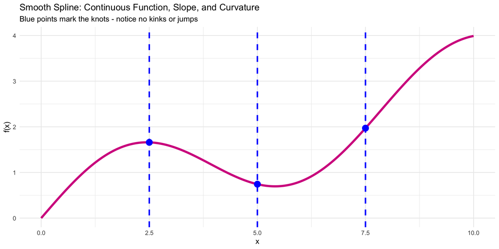

## Step 4: Natural Boundary Conditions

**Problem:** Cubic polynomials can oscillate wildly at the boundaries

**Solution:** Force the function to be **linear** beyond the outer knots

## Natural Boundary Condition

Beyond the boundary knots, set second derivative to zero:

$$f''(x) = 0 \text{ for } x < \xi_1 \text{ or } x > \xi_k$$

Since $f''(x) = 0$ for a cubic means linear, the tails are straight lines

## Why “Natural”?

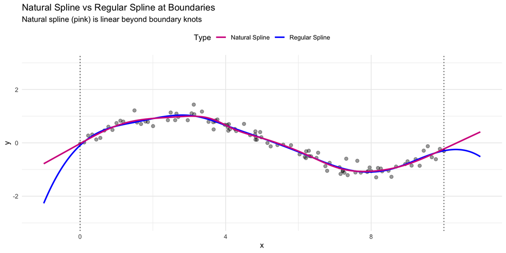

## Putting It All Together

1. **Choose knots** at quantiles
2. **Fit cubics** between knots
3. **Enforce smoothness** at knots (match function, slope, curvature)
4. **Go linear** at boundaries

**Result:** Smooth, flexible curve that doesn’t go crazy at the edges!

## From Constraints to Basis Functions

All these constraints determine a **basis**

Each basis function satisfies all the smoothness and boundary conditions

Our model is a **linear combination** of these basis functions:

$$f(x) = \beta_0 + \beta_1 b_1(x) + \beta_2 b_2(x) + \cdots + \beta_k b_k(x)$$

## The Basis Functions

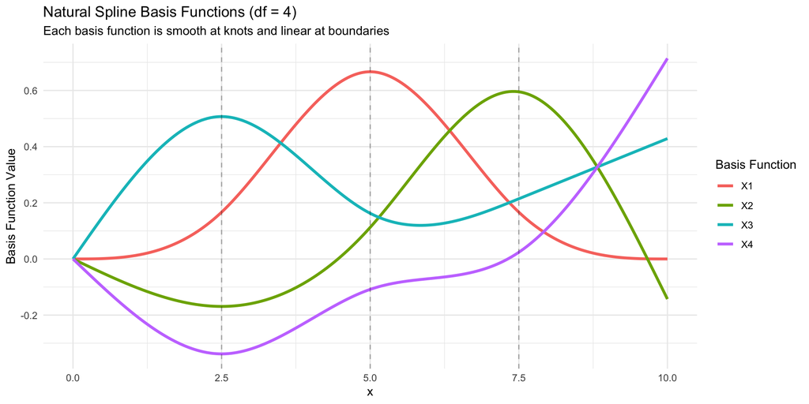